# DHH2021

Personal portfolio

Joni Oksanen

23.08.2021

# 1 DHH 2021 reflection

- our [GitHub](https://github.com/dhh21/semparl)
- our [final blog post at DHH21 blog](https://dhhackathon.wordpress.com/2021/05/28/semparl-cities-in-parliament/)
- our [Shiny app](https://jonioks.shinyapps.io/citiesinparl/)

I participated in the Digital Humanities Hackathon (DHH) 2021 as a team member in the Semantic parlament (Semparl) group. For the purposes of this hackathon, we were given access to [ParliamentSampo](https://seco.cs.aalto.fi/projects/semparl/en/), a work-in-progress search engine, where users can search for results from open data provided by the Finnish Parliament. In addition to word searches from text, the data in ParliamentSampo includes automatic background information of each document such as political party information for persons in the data and place names mentioned in the documents. After learning about the ParliamentSampo and how to use it, we started working from the initial topic of “politics and place”. We discussed our interest and backgrounds related to this project, our research theme was set on researching the development of city image in the Finnish parliamentary discussions during economic crises. Our final presentation in the form of a blog post can be read [here](https://dhhackathon.wordpress.com/2021/05/28/semparl-cities-in-parliament/)

My initial interest regarding participation in DHH2021, was to cooperate with people from various backgrounds and to learn and apply methods that I will use in my personal doctoral results, i.e. modern natural language processing and language modeling tools. My background consists of mostly working and studying the quantitative and computational domain. Few years ago, I was interested in working with text data and NLP, so I ended up writing my master’s thesis in statistics about training word embeddings. Before applying to the hackathon, I did not have any previous experience with digital humanities, besides my thesis. However, I was already familiar with the topics that were mentioned in the application form, but have not yet worked with the topics in the context of multidisciplinary research or collaboration.

The first days of the hackathon went so fast as we were trying to find the appropriate framework to conduct our study. After agreeing on the objectives of our brief, but in-depth analysis of parliamentary debates, I aligned myself in the data visualization and manipulation team. Both topics are something I have experience of working with and most of all enjoy spending time with. Even though my personal motivation to join the hackathon was learning something new by doing, I managed to get involved with things I have already done in the past. I did not mind this at all, as I noticed that I am actually good with these things as I immediately had ideas and how to produce them once someone mentioned visualizations. However, this hackathon was a learning event and I could have utilized the chance to do something new.

From a perspective of teamwork and collaborating within our team, I also thought that I would be the most productive by focusing on creating the final outputs (i.e. [plots](https://github.com/dhh21/semparl/blob/main/plots/financial_crisis_rate.gif), [Shiny applications](https://jonioks.shinyapps.io/citiesinparl/)) as there were not that many other team members with a quantitative background. I also did not want to take full control of the whole visualization part and offered the chance for others to be able to join or take lead in the data visualization process.

In general, participating in this 10 day hackathon was an insightful experience. Most of all, I enjoyed the discussions that we had about the research theme. It is not easy to find a common ground without someone making tradeoffs in multidisciplinary research. I learned from my team members how they approached data from the perspective of their own background and discipline and how their thinking process formulated the research questions that they wanted to examine and how their research questions would align with the interests of other team members. In addition, I believe I was able to teach R and also speak about what R is capable of (as most of our team had used mostly Python). I still had to cut down some parts from our final presentation as we simply did neither have the time to implement them completely nor present the results of these analyses during our presentation.

I also learned that it is important to take into account the time at your disposal. In this sense, the hackathon did not provide realistic settings as usually you don’t have only 10 days to plan *and* conduct your research. Taking into account the 10 days of hackathon, I think our topic was a bit too ambitious, but nevertheless we managed to deliver results, which I could have not expected to be produced from scratch within 10 days. I believe that our work was showcasing the possibilities of such an extensive linked data set by focusing on something else than examining the traditional party politics or policies. Among these reasons, I was inspired to continue some of the quantitative analyses that we had no time to complete during the hackathon, but we did produce data sets, which can be used in these analyses.

# 2 Further analysis

## 2.1 Data and observations

Our DHH work focused on more qualitative approach to find out how party politics and regional policies of MPs are represented and expressed in the dataset of parliamentary debates. One initial idea was to research if the MP’s own electoral district is mentioned more often than other places.

## 2.2 Limitations of data

As these analyses were conducted on the same datasets, which were used in our original DHH-analyses, the data is not fully applicable to thoroughly research if MPs really dicuss their own electoral district more often that other parts of Finland or how to normalize the number of mentions. Thus, the results of this report are not fully reliable, but the validity could improved if the data would be recollected considering the limitations and fixing thedeficiencies.

### 2.2.1 City name mentions

Following analyses were conducted using a dataset produced originally as a part of original DHH2021 research project “Cities in parliament”. Our previous study only examined 107 munincipalities, which have the [legal status of a city](https://en.wikipedia.org/wiki/List_of_cities_and_towns_in_Finland) as of 2021. There almost certainly is not included mentions, as the electoral district of Lappi includes only one city as the capital city of Helsinki is an electoral district of its own. Thus the results are highly biased towards highly populated areas, which include large cities.

### 2.2.2 Electoral distirct

The electoral district were added to cities by using the 2020 division provided by geofi package, which uses data provided by Statistics Finland. The historical names of each have been harmonized to match their current names, but the municipality level divison has not been taken into account. The some of borders of electoral districts have changed since 1986. The results reflect using the most current division, but they should been changed to reflect the regional division at the moment. However, similar regional divisions were only available from 2012. Having access to historical electoral districts would provide much more reliable results in this context. Also when examining the electoral district of MPs, the information was acquired from ParliamentSampo. If MP was selected from multiple districts, then the preceding information was discarded and the most recent districts was used. This is a limitation in ParliamentSampo biographies, not this analyses.

### 2.2.3 Parliamentary groups

If MP has been a member of multiple parliamentary groups during their career, only the latest information was used. Thus it is possible that a parliamentary group can show up in a time period before its inauguration. This information is also acquired from ParliamentSampo and it would be possible to time match the correct parliament group with the date of the plenary speech, but we had no time to implement this during DHH as party politics were not our team projects’ the first priority.

### 2.2.4 Time span

Our original study covered two 10-year periods: 1) depression in Finland in the 1990’s and 2) global financial crisis. This analyses is also separated in to these two periods, which cover 5 years before and after the peak/starting year of each economic crisis. Extending this research setting to cover larger period of time would more likely improve the reliability of the results. This quantitative examination is not really related to these economic crises, but we will use the data sets that were produced, but not analyzed during the hackathon.

## 2.3 Data and obervations

### 2.3.1 Municipality mentions by electoral district and year

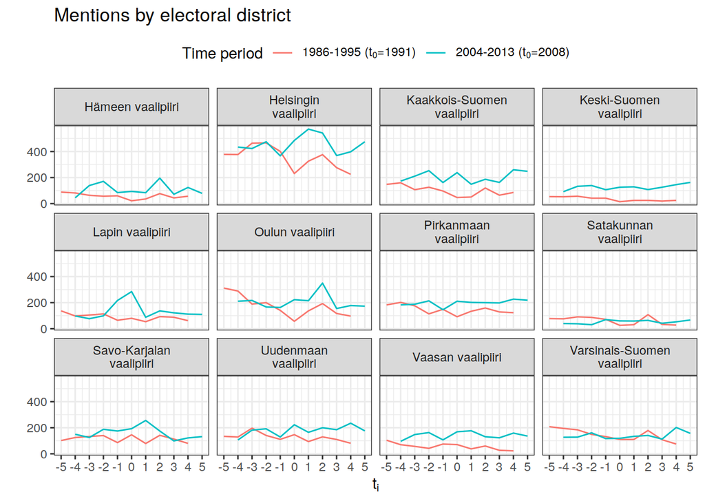

Figure 1

### 2.3.2 Municipality mentions by parliamentary group and year

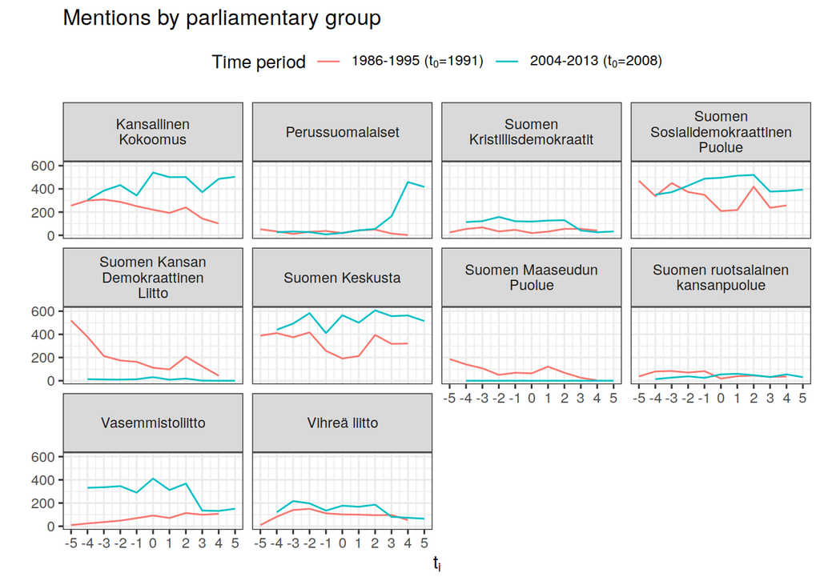

Figure 2

### 2.3.3 MPs mentioning regions in their own electoral disctric

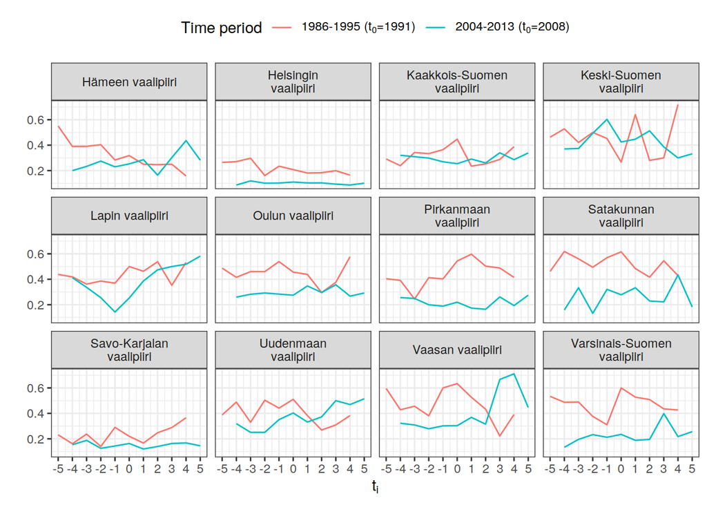

Figure 3

## 2.4 Interactive tools for data exploration

I have created a tool which allows users to explore the data themselves. In the first interactive selection user selects a electoral district and the maps presents how often MPs from the selected electoral district they have mentioned a municipality aggregated by electoral district. In the second selection user can select a parliamentary group and the maps visualizes which areas their MPs discuss in the plenary sessions aggregated by electoral district. One limitation of this map is that the electoral district division follows the borders of 2020 as it was the only openly available and creating datasets of historical electoral districts would be a project of its own.

The first set of maps can be used to explore if there is any change in how often the MPs speak about their own electoral district after a cutoff year. In this case, the maps follows the same economic crises (1990s depression in Finland and 2008 financial crisis) as our DHH work. Our initial motivation to examine this was the necessity of employment actions in certain area. This map answers to that question in a novel way by answering the question that did the number of mentions change after a defined time point, but it also can be used to compare MPs by electoral districts to see, if districts are mostly interested in talking about their own area or other areas, such as the capital region. Also this comparison aggregated the MPs by their electoral district meaning that the group of MPs is not influenced by a party programmes or policies of a single party.

The second set of maps can be used to examine which areas are the parliamentary groups interested in the most. The maps are similarly divided by the two economic crises to see if the interest in a certain geographical area has changed after a economic downfall. The maps work the best with parties that have many MPs during those periods. One major limitation is that these visualization are not taking the number of MPs in a parliamentary group into account as this historical information was not easily accessible.

## 2.5 Discussion

We could improve the reliable and validity of the results by fixing the limitations of the data. Fixing the issues related to data is time consuming and labor-intensive and implementing these changes would not really fit in the scope of the hackathon, but fixing them in this research or in ParliamentSampo data would not be impossible. However, this research is more of a novel example of what kind of research could be done related to regional policies and the geography of politics and how the results could be visually represented.

Similar tools could be developed to examine the effects of other events than just economic crises. For example before and after a change in party leadership or an ecological crisis, which took place in a certain area. Also to improve the quantitative representation of aggregated parliamentary groups, it would be crucial to include the number of MPs and re-examine the number of mentions normalized by the number of MPs in the parliamentary group.